# Overview of BayesianQDM

## Decisions in a proof-of-concept study

BayesianQDM implements the Bayesian quantitative decision-making framework of Kang, Yamaguchi and Han (2026) for proof-of-concept (PoC) studies. The data of a PoC study lead to one of three decisions: Go (proceed to the next phase of development), NoGo (stop the development) or Gray (the evidence is not sufficient for either decision).

Let $\theta$ be the treatment effect, the difference between the treatment and control groups in the response rate (binary endpoint), the mean (continuous endpoint) or the survival probability at a milestone time (time-to-event endpoint), or the ratio of the hazards of the two groups (time-to-event endpoint). The decision criteria use two values of the effect chosen by the study team: the target value $\theta_{TV}$, an effect worth pursuing, and the minimum acceptable value $\theta_{MAV} < \theta_{TV}$, below which the treatment is not of interest. Given the PoC data $D$, the criteria based on the posterior probability are

- Go criterion: $\Pr(\theta > \theta_{TV} \mid D) \ge \gamma_{go}$,
- NoGo criterion: $\Pr(\theta \le \theta_{MAV} \mid D) \ge \gamma_{nogo}$.

The decision is Go if only the Go criterion is met, NoGo if only the NoGo criterion is met, and Gray if neither is met. If both are met, which for one endpoint is possible only when $\gamma_{go} + \gamma_{nogo} \le 1$, the decision is called Miss; the package reports Miss decisions separately and warns when they have positive probability.

Kang et al. (2026) write the NoGo criterion as $\Pr(\theta > \theta_{MAV} \mid D) \le \gamma_2$. This is the same criterion with $\gamma_{nogo} = 1 - \gamma_2$, so a threshold $\gamma_2 = 0.2$ of the article corresponds to `gamma_nogo = 0.8`.

When smaller effects are favorable, as for the rate of an adverse event or a hazard ratio, `direction = "less"` in the criterion reverses the inequalities: the Go criterion is $\Pr(\theta < \theta_{TV} \mid D) \ge \gamma_{go}$ and the NoGo criterion is $\Pr(\theta \ge \theta_{MAV} \mid D) \ge \gamma_{nogo}$, with $\theta_{TV} < \theta_{MAV}$ (see `vignette("single-binary")` and `vignette("time-to-event")`).

The criteria can instead be based on the posterior predictive probability of the effect $\tilde\theta$ that will be observed in a future study with $m_t$ and $m_c$ subjects. With a null value $\theta_{NULL}$, the Go criterion is $\Pr(\tilde\theta > \theta_{NULL} \mid D) \ge \gamma_{go}$ and the NoGo criterion is $\Pr(\tilde\theta \le \theta_{NULL} \mid D) \ge \gamma_{nogo}$.

For two endpoints, the target values and minimum acceptable values divide the plane of $(\theta_1, \theta_2)$ into nine regions, and the criteria are based on the probabilities of unions of regions or on each endpoint separately (see `vignette("two-binary")` and `vignette("two-continuous")`).

## Specifying a study

A study is described by small specification objects, which are combined into a design.

| Function | Specifies |
| --- | --- |
| `prior_beta()`, `prior_nix()`, `prior_dirichlet()`, `prior_niw()`, `prior_gamma()`, `prior_vague()` | Prior distribution of one group |
| `data_binary()`, `data_continuous()`, `data_binary2()`, `data_continuous2()`, `data_tte()` | Summary of the data of one group |
| `borrow()` | External data and the weight $a_0$ of the power prior |
| `hypothetical()` | Hypothetical control for a study without a concurrent control group |
| `criterion_posterior()`, `criterion_predictive()` | Decision criterion |
| `conduct_tte()` | Enrollment, dropout and time of the analysis of a study with a time-to-event endpoint |
| `design_binary()`, `design_continuous()`, `design_binary2()`, `design_continuous2()`, `design_tte()` | Design of the study |
| `qdm_endpoint()` and the steps that follow it | Design of the study, built step by step (see below) |

The control group of a design takes one of four forms: a concurrent control group (`n_c` of at least 1 for binary and time-to-event endpoints, 2 for one continuous endpoint and 3 for two continuous endpoints), external control data only (`n_c = 0` and `external_c`), a hypothetical control (`n_c = 0` and `hypothetical_c`), or a fixed control (`n_c = 0` and `fixed_c`), a known value of the control parameter as in a single-arm study compared with a benchmark. External data can also be borrowed for the treatment group (`external_t`).

Six functions work with the designs.

| Function | Computes |
| --- | --- |
| `qdm_decide()` | The probabilities of the Go and NoGo regions and the decision for observed data |
| `qdm_oc()` | The operating characteristics: the probabilities of Go, NoGo, Gray and Miss decisions under scenarios for the true parameters |
| `qdm_compare()` | The operating characteristics of several designs under the same scenarios, in one table |
| `qdm_calibrate()` | The thresholds $\gamma_{go}$ and $\gamma_{nogo}$ that control the probabilities of a false Go and a false NoGo decision |
| `qdm_find_n()` | The smallest candidate sample size for which the probabilities of meeting the Go and NoGo criteria under two scenarios are at most given targets |
| `qdm_boundary()` | The observed data that lead to each decision, for example the numbers of responders, with the observed rates and effects (not available for two binary endpoints) |

## A first example

Consider a PoC study with one binary endpoint, 12 subjects in each group and Jeffreys priors $\textrm{Beta}(0.5, 0.5)$. The team chooses $\theta_{TV} = 0.2$, $\theta_{MAV} = 0.1$, $\gamma_{go} = 0.5$ and $\gamma_{nogo} = 0.8$.

```r
des <- design_binary(
  n_t = 12, n_c = 12,
  prior_t = prior_beta(0.5, 0.5), prior_c = prior_beta(0.5, 0.5),
  criterion = criterion_posterior(theta_tv = 0.2, theta_mav = 0.1,
                                  gamma_go = 0.5, gamma_nogo = 0.8)
)
des
```

```
#> Design: one binary endpoint
#>   Treatment: n = 12, prior Beta(a = 0.5, b = 0.5)
#>   Control: concurrent, n = 12, prior Beta(a = 0.5, b = 0.5)
#> Posterior probability criterion
#>   Go:   P(theta > 0.2 | data) >= 0.5
#>   NoGo: P(theta <= 0.1 | data) >= 0.8
```

If 9 of 12 subjects respond in the treatment group and 4 of 12 in the control group, the decision is:

```r
dec <- qdm_decide(des, data_t = data_binary(12, 9),
                  data_c = data_binary(12, 4))
dec
```

```
#> Decision: Go
#>   Go:   P(theta > 0.2 | data) = 0.8517 (threshold 0.5, met)
#>   NoGo: P(theta <= 0.1 | data) = 0.05935 (threshold 0.8, not met)
#> Posterior distributions
#>   Treatment: Beta(a = 9.5, b = 3.5)
#>   Control:   Beta(a = 4.5, b = 8.5)
```

The posterior probability that the effect exceeds the target value is 0.852, and the decision is Go.

The operating characteristics show how often the design leads to each decision. For a binary endpoint all outcomes of the study are enumerated, so the probabilities are exact.

```r
oc <- qdm_oc(des, data.frame(pi_t = seq(0.3, 0.7, by = 0.05), pi_c = 0.3))
oc
```

```
#> Operating characteristics (exact enumeration of the outcomes)
#>  pi_t pi_c     Go    NoGo   Gray Miss
#>  0.30  0.3 0.1316 0.41696 0.4514    0
#>  0.35  0.3 0.2032 0.31739 0.4794    0
#>  0.40  0.3 0.2893 0.23249 0.4782    0
#>  0.45  0.3 0.3860 0.16327 0.4507    0
#>  0.50  0.3 0.4883 0.10937 0.4023    0
#>  0.55  0.3 0.5906 0.06942 0.3399    0
#>  0.60  0.3 0.6875 0.04137 0.2711    0
#>  0.65  0.3 0.7742 0.02286 0.2030    0
#>  0.70  0.3 0.8472 0.01150 0.1413    0
```

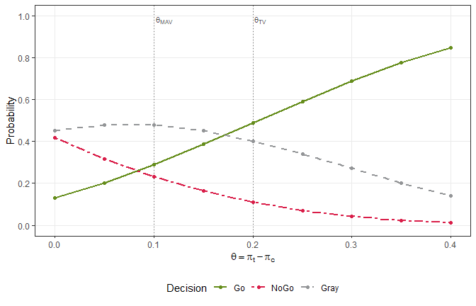

```r
plot(oc)
```

When the treatment has no effect ($\pi_t = \pi_c = 0.3$), the probability of a Go decision is 0.132. The thresholds can be calibrated so that the probability of meeting the Go criterion is at most 0.05 under no effect, and the probability of meeting the NoGo criterion is at most 0.2 when the effect is 0.3:

```r
cal <- qdm_calibrate(des,
                     scenario_go = data.frame(pi_t = 0.3, pi_c = 0.3),
                     scenario_nogo = data.frame(pi_t = 0.6, pi_c = 0.3),
                     target_go = 0.05, target_nogo = 0.2)
cal
```

```
#> Calibration of the decision thresholds (exact enumeration of the outcomes)
#>   gamma_go   = 0.74: P(Go criterion met | scenario_go) = 0.03587 (target 0.05)
#>   gamma_nogo = 0.39: P(NoGo criterion met | scenario_nogo) = 0.182 (target 0.2)
#> Decision probabilities with the chosen thresholds
#>       scenario pi_t pi_c      Go   NoGo   Gray Miss
#>    scenario_go  0.3  0.3 0.03587 0.7486 0.2155    0
#>  scenario_nogo  0.6  0.3 0.36483 0.1820 0.4531    0
```

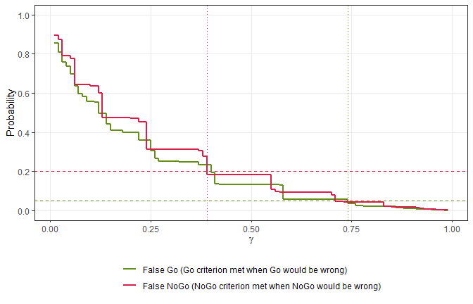

```r
plot(cal)
```

The calibrated thresholds are $\gamma_{go} =$ 0.74 and $\gamma_{nogo} =$ 0.39, and `cal$design` is the design with these thresholds, which can be passed to `qdm_decide()` and `qdm_oc()`. In the plot, the dashed horizontal lines are the targets and the dotted vertical lines are the chosen thresholds, in the colors of the criteria.

`qdm_boundary()` shows which observed data lead to each decision. For each number of control responders, it gives the numbers of treatment responders that lead to Go, NoGo and Gray decisions, the corresponding observed response rates of the treatment group and the observed differences in response rates:

```r
b <- qdm_boundary(des)
b
```

```
#> Decision boundary of a design with one binary endpoint
#>   n_t = 12, n_c = 12
#>
#> Responders in the treatment group (y_t)
#>   y_c   NoGo   Gray    Go
#>   0     0      1-2     3-12
#>   1     0-1    2-3     4-12
#>   2     0-1    2-4     5-12
#>   3     0-2    3-5     6-12
#>   4     0-3    4-6     7-12
#>   5     0-4    5-7     8-12
#>   6     0-5    6-8     9-12
#>   7     0-6    7-9     10-12
#>   8     0-7    8-10    11-12
#>   9     0-8    9-11    12
```

[output cut: 35 more lines]

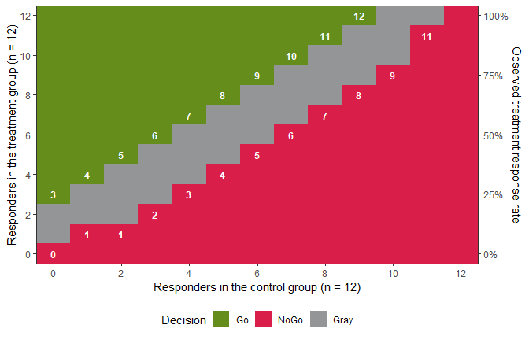

```r
plot(b)
```

The numbers written on the regions are the boundary values, such as the smallest number of treatment responders that leads to a Go decision. With 4 control responders, a Go decision needs at least 7 of the 12 treatment subjects to respond.

## Building a design step by step

A design can also be built step by step, for example with the native pipe `|>` of R. `qdm_endpoint()` starts a specification for an endpoint, and each of the other steps sets some arguments of the `design_*()` function of the endpoint:

| Step | Arguments |
| --- | --- |
| `qdm_sample_size()` | `n_t`, `n_c` |
| `qdm_prior()` | `prior_t`, `prior_c` |
| `qdm_criterion()` | `criterion` |
| `qdm_external()` | `external_t`, `external_c` |
| `qdm_control()` | `hypothetical_c`, `fixed_c` |
| `qdm_tte()` | `milestone`, `effect`, `conduct`, `conduct_future` (time-to-event endpoint) |
| `qdm_computation()` | `method`, `nMC`, `enumerate` |

```r
spec <- qdm_endpoint("binary") |>
  qdm_sample_size(n_t = 12, n_c = 12) |>
  qdm_prior(prior_t = prior_beta(0.5, 0.5),
            prior_c = prior_beta(0.5, 0.5)) |>
  qdm_criterion(criterion_posterior(theta_tv = 0.2, theta_mav = 0.1,
                                    gamma_go = 0.5, gamma_nogo = 0.8))
spec
```

```
#> Design specification (complete):
#> Design: one binary endpoint
#>   Treatment: n = 12, prior Beta(a = 0.5, b = 0.5)
#>   Control: concurrent, n = 12, prior Beta(a = 0.5, b = 0.5)
#> Posterior probability criterion
#>   Go:   P(theta > 0.2 | data) >= 0.5
#>   NoGo: P(theta <= 0.1 | data) >= 0.8
```

`qdm_build()` creates the design by calling `design_binary()` with these arguments, so it is the design `des` of the first example:

```r
identical(qdm_build(spec), des)
```

```
#> [1] TRUE
```

The steps only store their arguments, which are checked when the design is built, so the error messages are those of the `design_*()` function. A design created by a `design_*()` function can also start a pipe, and the steps then change parts of it. A step sets all its arguments anew, both when it is given again and when it is applied to a design (an argument that is not given returns to its default). The analyses (`qdm_decide()`, `qdm_oc()`, `qdm_compare()`, `qdm_calibrate()`, `qdm_find_n()` and `qdm_boundary()`) accept a specification and build it, so the pipe can go on to the analysis, here the operating characteristics with 20 subjects in each group:

```r
spec |>
  qdm_sample_size(n_t = 20, n_c = 20) |>
  qdm_oc(data.frame(pi_t = seq(0.3, 0.7, by = 0.1), pi_c = 0.3))
```

```
#> Operating characteristics (exact enumeration of the outcomes)
#>  pi_t pi_c      Go     NoGo   Gray Miss
#>   0.3  0.3 0.05948 0.437391 0.5031    0
#>   0.4  0.3 0.20255 0.202740 0.5947    0
#>   0.5  0.3 0.43851 0.070042 0.4914    0
#>   0.6  0.3 0.69555 0.016762 0.2877    0
#>   0.7  0.3 0.88485 0.002419 0.1127    0
```

`vignette("pipe")` gives more examples with the pipe, including `show_report()`, which writes the design and its results as a draft of the corresponding sections of a study protocol.

## Plots

The `plot()` methods return ggplot2 objects. Depending on the plot, their arguments set the colors of the decisions (`col_go`, `col_nogo`, `col_gray` and `col_miss`), the width of the lines (`linewidth`), the size of the points (`point_size`), the size of the text drawn in the plot (`label_size`), the base font size (`base_size`) and the position of the legend (`legend_position`); the help pages of `plot.qdm_oc()`, `plot.qdm_calibration()`, `plot.qdm_boundary()`, `plot.qdm_decision()`, `plot.qdm_comparison()` and `plot.qdm_n_search()` list them. Anything else can be changed by adding ggplot2 functions, as for any other ggplot2 plot:

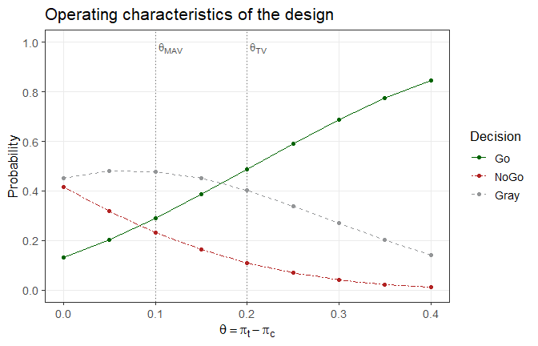

```r
plot(oc, col_go = "darkgreen", col_nogo = "firebrick", linewidth = 0.7,
     base_size = 13, legend_position = "right") +
  ggplot2::labs(title = "Operating characteristics of the design")
```

The plot of a decision shows how the observed data lead to it, here with the posterior density of the treatment effect and the Go and NoGo regions:

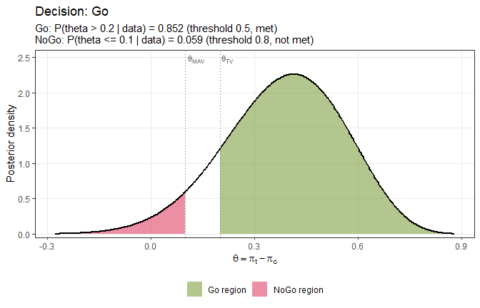

```r
plot(qdm_decide(des, data_t = data_binary(12, 9),
                data_c = data_binary(12, 4)))
```

## Endpoints and computation

| Endpoints | Design | Model | Probabilities of the regions | Operating characteristics |
| --- | --- | --- | --- | --- |
| One binary | `design_binary()` | Beta-binomial | Numerical integration (posterior), exact sum (predictive) | Exact enumeration |
| One continuous | `design_continuous()` | Normal-Inverse-chi-squared or vague | Numerical integration (`"NI"`), moment matching (`"MM"`) or Monte Carlo (`"MC"`) | Simulation of `nsim` studies |
| Two binary | `design_binary2()` | Dirichlet-multinomial | Monte Carlo with `nMC` draws (posterior), exact sum (predictive) | Exact enumeration or simulation |
| Two continuous | `design_continuous2()` | Normal-Inverse-Wishart or vague | Moment matching (`"MM"`) or Monte Carlo (`"MC"`) | Simulation of `nsim` studies |
| One time-to-event | `design_tte()` | Exponential with Gamma prior (milestone survival or hazard ratio) | Numerical integration or F distribution (posterior), simulation of `nMC` future studies (predictive) | Simulation of `nsim` studies |

The posterior distributions have closed forms, including those with external data borrowed through a power prior, so Markov chain Monte Carlo sampling is not needed. With a fixed control, the probabilities depend only on the posterior distribution of the treatment group and are computed from closed forms or by numerical integration, except for the posterior probabilities of two binary endpoints and the predictive probabilities of a time-to-event endpoint, which are Monte Carlo estimates. For one continuous endpoint, numerical integration is exact up to a small numerical error; the moment-matching approximation is faster by about two orders of magnitude for operating characteristics and is suited to exploring designs, and the chosen design can then be checked with numerical integration. For two continuous endpoints, the moment-matching approximation can be checked with Monte Carlo estimates. The computing time of Monte Carlo estimates is proportional to the number of draws, and that of simulated operating characteristics to `nsim`.

## Random numbers

`qdm_decide()`, `qdm_oc()`, `qdm_compare()`, `qdm_calibrate()`, `qdm_find_n()` and `qdm_boundary()` have a `seed` argument for the random numbers they use (simulated studies and Monte Carlo estimates of probabilities). With `seed = NULL` (the default) they use the current random number stream, so `set.seed()` makes the results reproducible. With a given seed, the computation uses that seed and the previous state of the random number generator is restored on exit. `ptdiff()` with `method = "MC"` and `rdirichlet()` always use the current random number stream.

When the operating characteristics are simulated, the thresholds chosen by `qdm_calibrate()` and the sample size chosen by `qdm_find_n()` can change with the simulation error if the probabilities are close to the targets, so a larger `nsim` (and `nMC`) than for exploring designs is advisable for the final design.

## Validation

The scripts in the folder `validation` of the installed package compare BayesianQDM with published and submitted results (Kang et al., 2026; Huang, Talukder, Han and Kuan, 2019; Huang et al., submitted; Yamaguchi, Homma, Takeda and Maruo, submitted; Yamaguchi et al., submitted). The file `results/summary.md` in that folder reports the comparisons, with a registered reason for every difference beyond rounding:

```r
system.file("validation", "results", "summary.md", package = "BayesianQDM")
```

## Further reading

- `vignette("pipe")`: designs and analyses built with the pipe, and reports for a study protocol.
- `vignette("planning")`: scenarios, comparison of designs, search for the sample size, tables of results, the plot of a decision and the R code of a design.
- `vignette("single-binary")`: one binary endpoint.
- `vignette("single-continuous")`: one continuous endpoint.
- `vignette("two-binary")`: two binary endpoints.
- `vignette("two-continuous")`: two continuous endpoints.
- `vignette("time-to-event")`: one time-to-event endpoint.
- `vignette("migration")`: translating code written for version 0.1.0.

## References

Huang, B., Talukder, E., Han, L. and Kuan, P.-F. (2019). Quantitative decision-making in randomized Phase II studies with a time-to-event endpoint. *Journal of Biopharmaceutical Statistics*, 29(1), 189–202. https://doi.org/10.1080/10543406.2018.1489400

Huang, Y., Yamaguchi, Y., Homma, G., Takeda, K. and Maruo, K. (submitted). Conjugate representation of power priors for efficient Bayesian analysis of normal data.

Kang, R., Yamaguchi, Y. and Han, C. (2026). Bayesian quantitative decision-making framework in cell and gene therapy development for rare diseases. *Journal of Biopharmaceutical Statistics*. https://doi.org/10.1080/10543406.2026.2655410

Yamaguchi, Y., Homma, G., Takeda, K. and Maruo, K. (submitted). Moment-matching approximation for t-differences in clinical trials with continuous endpoints.

Yamaguchi, Y., Hu, H., Huang, Y., Han, C., Homma, G. and Wang, A. (submitted). Bivariate Bayesian quantitative decision-making for two endpoints in rare disease drug development.